# spatial_sim

## Spatial Transcriptomics simulation with spatial dependencies

- **Fix library-size sampling noise**  
  We sample single cell indices with similar library size to the same synthetic spots.
- **Add spatial dependencies with 2D Gaussian Process simulations**  
  There is smooth transition of both cell-type specific and overall spatial density patterns (e.g. similar density for adjacent spots).

```python
import os
import sys
import math
import json

import numpy as np
import pandas as pd
import seaborn as sns
import pymc3 as pm

import scanpy as sc
import torch
import gpytorch

import matplotlib.pyplot as plt
```

### Cell2Location simulation

**Step 1: simulate per cell abundance for each spatial pattern**

Note: exponentiated quadratic kernel: $k(x_1, x_2) = \sigma^2 \exp{- \dfrac{\Vert x_1 - x_2 \Vert^2}{2 l^2}}$

- $\sigma^2$: overall variance (amplitude)
- $l$: lengthscale

```python
# Code from cell2location simulations
# Reference: https://github.com/vitkl/cell2location_paper

def kernel(X1, X2, l=1.0, eta=1.0):
    """
    Isotropic squared exponential kernel. Computes
    a covariance matrix from points in X1 and X2.

    Args:
        X1: Array of m points (m x d).
        X2: Array of n points (n x d).

    Returns:
        Covariance matrix (m x n).
    """
    sqdist = np.sum(X1**2, 1).reshape(-1, 1) + np.sum(X2**2, 1) - 2 * np.dot(X1, X2.T)
    return eta**2 * np.exp(-0.5 / l**2 * sqdist)

def generate_grid(n=[50, 50]):
    n1, n2 = n
    x1 = np.linspace(0, 100, n1)[:,None] #saptial dimensions
    x2 = np.linspace(0, 100, n2)[:,None] #saptial dimensions

    # make cartesian grid out of each dimension x1 and x2
    return pm.math.cartesian(x1[:,None], x2[:,None]), x1, x2

def random_GP(X,
              x1=1, x2=1, #coordinates
              n_variables = 5, # zones
              eta_true = 5, #variance, defines overlapping
              l1_true=[8, 10, 15], #bw parameter
              l2_true=[8, 10, 15]
             ):

    #cov1, cov2 = kernel(x1, x1, l=l1_true), kernel(x2, x2, l=l2_true)
    K = [np.kron(kernel(x1, x1, l=l1_true[i], eta=eta_true),
                 kernel(x2, x2, l=l2_true[i], eta=eta_true))
         for i in range(n_variables)]

    #samples from GP
    gaus_true = np.stack([
        np.random.multivariate_normal(np.zeros(X.shape[0]), 2*K[i])
        for i in range(n_variables)
    ]).T

    N_true = (np.exp(gaus_true).T / np.exp(gaus_true).sum(axis=1)).T #softmax transform
    return N_true


# TODO:
# Try increasing GP eta (variance) value --> more inhomogenous cell-type density
def sample_GP(locations,
              ct_labels,
              n_spec,
              n_ubiq,
              bw_spec,
              bw_ubiq,
              x1,
              x2,
              eta_spec=2,
              eta_ubiq=1
             ):
    """
    Sample abundances with GP

        Higher `eta` values represent higher transition rates
        from high-density <--> low -density region

    """
    sparse_abundances = random_GP(
        X=locations,
        x1=x1,
        x2=x2,
        n_variables=n_spec,
        eta_true=eta_spec,
        l1_true=bw_spec,
        l2_true=bw_spec
    )

    sparse_abundances = sparse_abundances / sparse_abundances.max(0)
    sparse_abundances[sparse_abundances < 0.1] = 0

    uniform_abundances = random_GP(
        X=locations,
        x1=x1,
        x2=x2,
        n_variables=n_ubiq,
        eta_true=eta_ubiq,
        l1_true=bw_ubiq,
        l2_true=bw_ubiq
    )

    uniform_abundances = uniform_abundances / uniform_abundances.max(0)
    uniform_abundances[uniform_abundances < 0.1] = 0

    abundances = np.concatenate([sparse_abundances, uniform_abundances], axis=1)

    return pd.DataFrame(
        abundances,
        index=[f'location_{i}' for i in range(abundances.shape[0])],
        columns=ct_labels
    )


def plot_spatial(values, n=[50,50], nrows=5, names=['cell type'],
                 vmin=0, vmax=1):

    n_cell_types = values.shape[1]
    n1, n2 = n
    ncols = np.ceil((n_cell_types+1) / nrows).astype(np.uint16)
    for ct in range(n_cell_types):
        try:
            plt.subplot(nrows, ncols, ct+1)
            plt.imshow(values[:,ct].reshape(n1,n2).T,
                       cmap=plt.cm.get_cmap('magma'),
                       vmin=vmin, vmax=vmax
                      )
            plt.colorbar()
            if len(names) > 1:
                plt.title(names[ct])
            else:
                plt.title(f'{names[0]} {ct+1}')

        except ValueError:
            continue

    try:
        plt.subplot(nrows, ncols, n_cell_types+1)
        plt.imshow(values.sum(axis=1).reshape(n1,n2).T,
                   cmap=plt.cm.get_cmap('Greys'))
        plt.colorbar()
        plt.title('total')

    except ValueError as e:
        print(e)
```

**Modification:**  
Direct assignment of ubiquitous & specific cell types:

- Ubiquitous: B-cell, T-cell, Endothelial, Plasmablast
- Specific: Normal_Epithelial, Cancer_Epithelial, CAFs, PVL, Myeloid

(Note: unify cell-type names: Cancer_Epithelial = TNBC)

```python
def get_ct_name(ct_map, idxs):
    try:
        return [ct_map[i] for i in idxs]
    except KeyError(e):
        print('Index {} not included in cell type map'.format(i))
        return -1
```

```python
# Define cell types & cell-type assignment to spatial patterns
ct_names = [
    'B-cells',
    'CAFs',
    'Endothelial',
    'Normal_Epithelial',
    'Myeloid',
    'PVL',
    'Plasmablasts',
    'T-cells',
    'Cancer_Epithelial'
]

ubiq_ct_names = [
    'B-cells',
    'Endothelial',
    'T-cells',
    'Plasmablasts'
]

spec_ct_names = [
    'CAFs',
    'Normal_Epithelial',
    'Myeloid',
    'PVL',
    'Cancer_Epithelial'
]

ct_maps = {i: ct for (i, ct) in enumerate(ct_names)}

n_cts = len(ct_names) # number of cell types
n_spec_cts = len(spec_ct_names)
n_ubiq_cts = len(ubiq_ct_names)

spec_cell_types = [
    idx
    for idx, name in enumerate(ct_names)
    if name in set(spec_ct_names)
]

ubiq_cell_types = [
    idx
    for idx, name in enumerate(ct_names)
    if name in set(ubiq_ct_names)
]

# numerical representation of cell types (NOTE: order super important!)
cell_types = np.concatenate([spec_cell_types, ubiq_cell_types])
```

**TODO**

Simulate whole canvas and mask out tissue regions with true spatial regions (simualate hotspot of specific cell types (using localized patterns).

Load image & spot coordinates:

```python
from skimage import io
import json
```

```python
# Please re-specify the spatial data path
# Data: CID44971
spatial_path = '../../data/wu_data/CID44971/st/'
sample_id = 'CID44971'


# Load real ST data (CID44971)
adata = sc.read_h5ad(
    os.path.join(spatial_path, sample_id+'.h5ad')
)

adata.var_names_make_unique()

# Load image & locations
"""
with open('../../data/1a/spatial/scalefactors_json.json', 'r') as f:
    scale_info = json.load(f)
    scale = scale_info['tissue_hires_scalef']

locs = np.round(adata.obsm['spatial'] * scale).astype(int)
size = hist_img.shape
"""
print()
```

```python
def _random_assign(n):
    """Random one-to-one assignemnt by permuting an NxN identity matrix"""
    mat = np.random.permutation(np.diag(np.ones(n)))
    return mat

def assign_ct_pattern(ubiq_cts,
                      spec_cts,
                      n_spec_patterns,
                      n_ubiq_patterns,
                     ):
    """
    Assign cell-type categories to spatial pattern categories
    """
    n_ubiqs = len(ubiq_cts) # number of ubiquitous cell types
    n_specs = len(spec_cts) # number of specific cell types

    # Modification:
    # For both ubiquitous & spatial pattern, only allow one-to-one mapping
    spec_assignment = _random_assign(n_spec_patterns)
    ubiq_assignment = _random_assign(n_ubiq_patterns)

    """
    ubiq_assignment = np.random.binomial(
        n=1,
        p=0.4,
        size=(len(ubiq_cts), n_ubiq_patterns)
    )
    """

    mat_spec = np.concatenate(
        (spec_assignment,
         np.zeros((len(spec_cts), n_ubiq_patterns))
        ),
        axis=1
    )

    mat_ubiq = np.concatenate(
        (np.zeros((len(ubiq_cts), n_spec_patterns)),
         ubiq_assignment
        ),
        axis=1
    )

    idx_names = np.concatenate((spec_cts, ubiq_cts))
    col_names = ['Spec_'+str(i+1) for i in range(n_spec_patterns)] + \
                ['Ubiq_'+str(i+1) for i in range(n_ubiq_patterns)]


    patterns_df = pd.DataFrame(
        np.concatenate(
            (mat_spec, mat_ubiq),
            axis=0
        ).astype(np.uint8),
        index=idx_names,
        columns=col_names
    )

    patterns_df.index.name='cell_types'

    return patterns_df
```

Increase GP bandwidth:

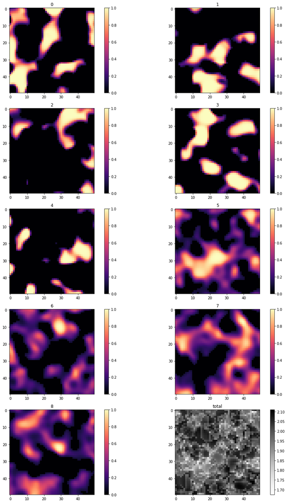

```python
# Generate matrix of which cell types are in which zones
# Specify number of distinct spatial patterns under each category
"""
    Assignment of cell-type to specific spatial patterns
    (either `Spec` - specific or `Ubiq` - Ubiquitous)
"""


np.random.seed(1000)
n_experiments = 1
n_locations = [50, 50]

ct_patterns_df = assign_ct_pattern(
    ubiq_cell_types,
    spec_cell_types,
    n_spec_patterns=n_spec_cts,
    n_ubiq_patterns=n_ubiq_cts
)

# Sample bandwidth parameter
mean_var_ratio = 1.5
mean_spec = 12
mean_ubiq = 8

bandwidth_spec = np.random.gamma(
    mean_spec * mean_var_ratio, 1 / mean_var_ratio,
    size=n_spec_cts
)

bandwidth_ubiq = np.random.gamma(
    mean_ubiq * mean_var_ratio, 1 / mean_var_ratio,
    size=n_ubiq_cts
)

locations_1, x1, x2 = generate_grid(n=n_locations)
locations = np.concatenate([locations_1 for _ in range(n_experiments)], axis=0)


# Sample per-cell-type, per-spot abundance
abundances_df = pd.DataFrame()
for e in range(n_experiments):

    abundances_df_1 = sample_GP(
        locations=locations_1,
        ct_labels=cell_types,
        n_spec=n_spec_cts,
        n_ubiq=n_ubiq_cts,
        bw_spec=bandwidth_spec,
        bw_ubiq=bandwidth_ubiq,
        x1=x1, x2=x2
    )

    abundances_df_1.index = [f'exper{e}_{l}' for l in abundances_df_1.index]
    abundances_df = pd.concat((abundances_df, abundances_df_1), axis=0)

    plt.figure(figsize=(2*5+5,3*5+5))
    plot_spatial(abundances_df_1.values, n=n_locations, nrows=5, names=np.arange(n_cts+1))
    plt.tight_layout()
    plt.show()
```

Generate per-spot spatial pattern:  
For each cell type:

- matrix dot spatial pattern `abundance_df` with binary assignment of spatial patterns `ct_patterns_df`  
  Variable notation:
  - `abundance_df` ($\mathbb{R}^{s \times f}$): spatial abundance for each pattern
  - `ct_patterns_df`: binary assignment of which cell type belongs to which spatial pattern
  - `cell_abundances_df` ($\mathbb{R}^{s \times f}$): spatial abundance for each cell type & spot

Latest modification:  
For each cell type, we simulate independent $q_{s,c,f}$, the multiplier to generate cell abundance from spatial pattern assigment (0, 1)

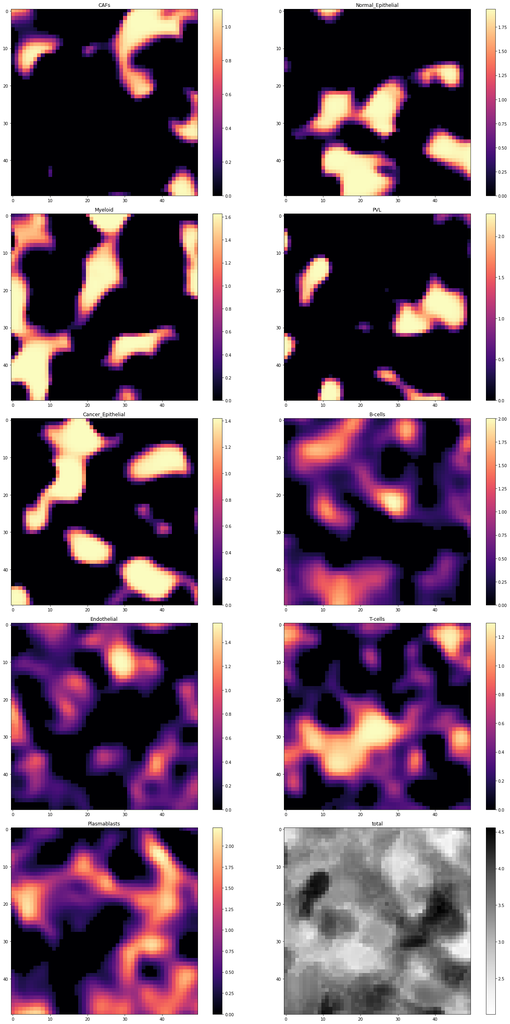

```python
np.random.seed(1000)

cell_abundances = np.dot(abundances_df, ct_patterns_df.T)


q_sf = np.tile(
    np.random.lognormal(0.5, 0.5, size=n_cts),
    reps=(n_locations[0] * n_locations[1], 1),
)

cell_abundances = cell_abundances * q_sf
cell_abundances_df = pd.DataFrame(
    cell_abundances,
    index=abundances_df.index,
    columns=ct_patterns_df.index
)

cell_abundances_df.columns = spec_ct_names + ubiq_ct_names

plt.figure(figsize=(3*5+5, 3*10+5))
plot_spatial(cell_abundances_df.values,
             n=n_locations, nrows=5,
             names=cell_abundances_df.columns, vmax=None)
plt.tight_layout()
plt.show()
```

Discretize spot-wise cell count from cell_abundances by taking `ceiling`  
Generate ground-truth proportions:

```python
cell_count_df = np.ceil(cell_abundances_df).astype(np.uint16)
proportion_df = cell_count_df / np.expand_dims(cell_count_df.sum(1), 1)
```

```python
cell_count_df.sum(1).value_counts()
```

```
6    987
5    749
7    419
4    264
8     65
3     15
9      1
dtype: int64
```

```python
proportion_df.head()
```

|  | CAFs | Normal_Epithelial | Myeloid | PVL | Cancer_Epithelial | B-cells | Endothelial | T-cells | Plasmablasts |
| --- | --- | --- | --- | --- | --- | --- | --- | --- | --- |
| exper0_location_0 | 0.200000 | 0.0 | 0.200000 | 0.000000 | 0.0 | 0.20 | 0.2 | 0.200000 | 0.000000 |
| exper0_location_1 | 0.250000 | 0.0 | 0.250000 | 0.000000 | 0.0 | 0.25 | 0.0 | 0.250000 | 0.000000 |
| exper0_location_2 | 0.250000 | 0.0 | 0.250000 | 0.000000 | 0.0 | 0.00 | 0.0 | 0.500000 | 0.000000 |
| exper0_location_3 | 0.200000 | 0.0 | 0.400000 | 0.000000 | 0.0 | 0.00 | 0.0 | 0.400000 | 0.000000 |
| exper0_location_4 | 0.166667 | 0.0 | 0.166667 | 0.166667 | 0.0 | 0.00 | 0.0 | 0.333333 | 0.166667 |

**Step 2**

Sample cell indices from scRNA-seq for each spot, construct synthetic `(S x G)` counts by sampling cells with similar library size.

(1). Load scRNA-seq matrix counts & metadata (cell-type annotation)

```python
sc_path = '../../sc_transcriptome_ana/data/wu_data/CID44971/scrna/'

# scRNA-seq count matrix
df_sc = pd.read_csv(
    os.path.join(sc_path, 'bc_sc.csv'),
    index_col=[0],
    header=[0]
)

# scRNA-seq metadata
df_meta = pd.read_csv(
    os.path.join(sc_path, 'metadata.csv'), index_col=[0]
)

annots = df_meta['celltype_major']
df_sc.index.name = 'Barcode'
df_sc['cell_type'] = annots.to_list()
df_sc.set_index('cell_type', inplace=True, append=True)
```

```python
annots.value_counts()
```

```
T-cells              4366
Cancer_Epithelial     894
Normal_Epithelial     735
Myeloid               684
CAFs                  582
B-cells               369
Endothelial           217
PVL                    91
Plasmablasts           48
Name: celltype_major, dtype: int64
```

```python
df_sc.head()
```

| Barcode | cell_type | RP11-34P13.7 | FO538757.3 | FO538757.2 | AP006222.2 | RP4-669L17.10 | RP5-857K21.4 | RP11-206L10.9 | LINC00115 | FAM41C | RP11-54O7.3 | ... | GRXCR1 | RP11-63A1.2 | CTD-2514K5.4 | RP11-112L7.1 | RP11-231G15.2 | RP11-983C2.3 | LINC00919 | RP11-589P10.7 | KRTAP9-2 | IGLVIV-66-1 |
| --- | --- | --- | --- | --- | --- | --- | --- | --- | --- | --- | --- | --- | --- | --- | --- | --- | --- | --- | --- | --- | --- | --- |
| CID44971_AAGCCGCCACGCATCG | Endothelial | 0 | 0 | 0 | 0 | 0 | 0 | 0 | 0 | 0 | 0 | ... | 0 | 0 | 0 | 0 | 0 | 0 | 0 | 0 | 0 | 0 |
| CID44971_AAGGAGCTCAACACAC | Endothelial | 0 | 0 | 0 | 0 | 0 | 0 | 0 | 0 | 0 | 0 | ... | 0 | 0 | 0 | 0 | 0 | 0 | 0 | 0 | 0 | 0 |
| CID44971_ACGAGCCTCCGATATG | Endothelial | 0 | 0 | 0 | 0 | 0 | 0 | 0 | 0 | 0 | 0 | ... | 0 | 0 | 0 | 0 | 0 | 0 | 0 | 0 | 0 | 0 |
| CID44971_ACGTCAATCCGAAGAG | Endothelial | 0 | 0 | 0 | 0 | 0 | 0 | 0 | 0 | 0 | 0 | ... | 0 | 0 | 0 | 0 | 0 | 0 | 0 | 0 | 0 | 0 |
| CID44971_AGAGTGGCACACGCTG | Endothelial | 0 | 0 | 0 | 0 | 0 | 0 | 0 | 0 | 0 | 0 | ... | 0 | 0 | 0 | 0 | 0 | 0 | 0 | 0 | 0 | 0 |

5 rows × 29733 columns

(2). Fit raw library size with $\text{LogNormal}$ distribution:

**Fix inhomogeneous library size for spots captured by same synthetic spots**

```python
from scipy.stats import lognorm, poisson, gamma
```

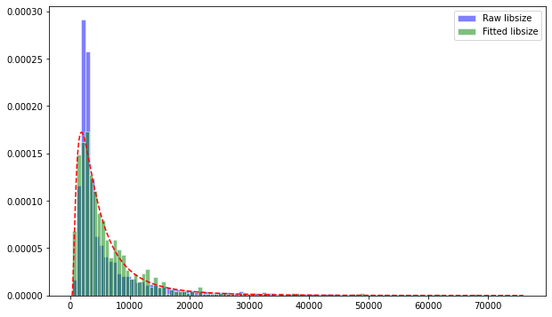

```python
# Fit library size r.v. with scRNA-seq data
# plot the original histogram with the simulated one from fitted parameters

libsize = df_sc.values.sum(1)
s, loc, scale = lognorm.fit(libsize)

rvs = lognorm.rvs(s, loc=loc, scale=scale, size=1000)
plt.figure(figsize=(10, 6))

plt.hist(libsize, bins=100, density=True, label='Raw libsize',
         color='blue', edgecolor='white', alpha=0.5)
plt.hist(rvs, bins=100, density=True, label='Fitted libsize',
         color='green', edgecolor='white', alpha=0.5)

x = np.linspace(libsize.min(), libsize.max(), len(libsize)+1)
pdf = lognorm.pdf(x, s, loc, scale)
plt.plot(x, pdf, '--', color='r')
plt.legend()

plt.show()
```

(3). Generate spot x gene matrix by synthesizing `pseudo-spots` with cell-type specific density & library-size

Some visualization (archived):

```python
# Visualize cell count per cell-type
plt.figure(figsize=(3*5+5, 3*10+5))

plot_spatial(cell_count_df.values,
             n=n_locations, nrows=4,
             names=cell_abundances_df.columns, vmax=None)
```

```python
# Visualize per cell-type capture rate
eps = 1e-10

cell_capture_rate_df = cell_abundances_df / (cell_count_df + eps)

plt.figure(figsize=(3*5+5, 3*10+5))
plot_spatial(cell_capture_rate_df.values,
             n=n_locations, nrows=4,
             names=cell_abundances_df.columns, vmax=None)

plt.suptitle('Capture rate per cell type', y=0.9, fontsize=20)
plt.show()
```

```python
# Visualize avg. cell count per spot
fig, (ax1, ax2) = plt.subplots(1, 2, figsize=(11, 5))

sns.heatmap(cell_count_df[cell_count_df>0].mean(1).values.reshape(50, -1), ax=ax1)
ax1.set_title('Avg. non-empty cell count per spot')
ax1.axis('off')

sns.heatmap(cell_count_df[cell_count_df>0].var(1).values.reshape(50, -1), ax=ax2)
ax2.set_title('Variance of non-empty cell count per spot')
ax2.axis('off')

plt.tight_layout()
plt.show()
```

Simulate library size for each spot:

First, Check overall capture ratio from scRNA-seq to visium (CID44971 scRNA - CID44971 ST)

We scale the true capture ratio from scRNA-seq to ST as follows:  
Median library size ratio ($r = \dfrac{\text{ST library size}}{\text{scRNA-seq library size}}$) divided by average `# cells` captured within each synthetic spot:

$$r_{scaled} = \dfrac{r}{\text{avg. # cells captured}}$$

```python
libsize = df_sc.values.sum(1)
libsize_st = adata.X.A.sum(1)

cap_ratio = np.median(np.log1p(libsize_st)) / np.median(np.log1p(libsize))
cap_ratio_per_spot = cap_ratio / cell_count_df.sum(1).mean()
cap_ratio_per_spot
```

```
0.20073582166511109
```

```python
def find_nonzero_cts(df):
    """
    Find expressed (non-zero) cell types per spot
    """
    cols = df.columns
    return (df > 0).apply(
        lambda x: list(cols[x.values]), axis=1
    )


def find_sc_index(df, cell_type, libsize_raw, l, n_nbr=3):
    """
    Find the scRNA-seq cell with close library size to given expected library size of
    the synthetic spot (s).

    Either randomly sample the index out of n closest libsize or
    deterministically choose the cell index with the closest libsize

    Returns
    -------
    expr : list
        Gene expression of the selected scRNA-seq cell
    """

    # Bug: the index in subsetted libsize different from the original count index!!!
    cell_types = np.unique(df.index.get_level_values(1))
    assert cell_type in cell_types, 'Unexpected cell type {}'.format(cell_type)

    # 'Mask out' indices other than the given cell type
    mask = df.index.get_level_values(1) == cell_type
    libsize = libsize_raw.copy()
    libsize[~mask] = -np.inf

    n = np.random.randint(n_nbr) if n_nbr > 0 else 0
    idx = np.abs(libsize - l).argsort()[n]
    expr = df.iloc[idx].to_numpy()

    return expr


def fit_st_libsize(libsize, idxs):
    """
    Fit library size from scRNA-seq data & sample expected library size
    to each synthetic Spatial Transcriptomics spot
    """

    s, loc, scale = lognorm.fit(libsize)
    l = pd.Series(
        lognorm.rvs(s, loc=loc, scale=scale, size=len(idxs)),
        index=idxs
    )

    return np.round(l).astype(np.uint32)


def simulate_spots(df, count_df, expr_factors, l, ratio=0.16, verbose=False):
    """
    Simulate spot x gene synthetic matrix given
    (1). per-cell density; (2). library size for each spot
    """
    n_spot = count_df.shape[0]
    n_genes = df.shape[1]
    libsize = df.sum(1).to_numpy().astype(np.float64)

    sims = np.zeros((n_spot, n_genes))

    for i, cell_types in enumerate(expr_factors):
        if verbose and i % 100 == 0:
            print('Simulating spot {}...'.format(i))

        l_s = l[i] # expected library size for given spot
        spot_expr = np.zeros(n_genes)

        cell_count = count_df[cell_types].iloc[i]
        n_cells = cell_count.sum().astype(np.uint32)

        # Sample expected library size to each single-cell index
        # captured to current spot
        # for now fix the same expected library size for all scRNA-seq to the given spot
        """
        expected_libsize = poisson.rvs(
            l[i],
            size=n_cells
        )
        """

        cell_type_freqs = np.hstack([
            np.repeat(cell_type, count)
            for (cell_type, count) in zip(cell_types, cell_count)
        ])

        # for count, cell_type in zip(expected_libsize, cell_type_freqs):
        for cell_type in cell_type_freqs:
            ct_expr = find_sc_index(df, cell_type, libsize, l_s, n_nbr=0)
            spot_expr += ct_expr

        spot_expr = np.round(spot_expr * ratio).astype(np.uint64)
        sims[i] = spot_expr

    sims_df = pd.DataFrame(
        sims,
        index=count_df.index,
        columns=df.columns
    )

    return sims_df
```

- Sample library size $l_s$ for each synthetic spot from the r.v. fitted from scRNA-seq.  
  ($l_s$ restricts the max. number of gene expression count for each spot $s$)
- Simulate synthetic expression ($X_{s,g}$):

```python
# Get list of expressed (non-zero) cell type for each spot
expressed_factors = find_nonzero_cts(cell_count_df)

# Fit library size to each synthetic spot
l_s = fit_st_libsize(
    libsize=df_sc.values.sum(1),
    idxs=cell_abundances_df.index
)

synth_df = simulate_spots(
    df_sc,
    cell_count_df,
    expressed_factors,
    l_s,
    ratio=cap_ratio_per_spot,
    verbose=True
)
```

```
Simulating spot 0...
Simulating spot 100...
Simulating spot 200...
Simulating spot 300...
Simulating spot 400...
Simulating spot 500...
Simulating spot 600...
Simulating spot 700...
Simulating spot 800...
Simulating spot 900...
Simulating spot 1000...
Simulating spot 1100...
Simulating spot 1200...
Simulating spot 1300...
Simulating spot 1400...
Simulating spot 1500...
Simulating spot 1600...
Simulating spot 1700...
Simulating spot 1800...
Simulating spot 1900...
Simulating spot 2000...
Simulating spot 2100...
Simulating spot 2200...
Simulating spot 2300...
Simulating spot 2400...
```

```python
synth_df.head()
```

|  | RP11-34P13.7 | FO538757.3 | FO538757.2 | AP006222.2 | RP4-669L17.10 | RP5-857K21.4 | RP11-206L10.9 | LINC00115 | FAM41C | RP11-54O7.3 | ... | GRXCR1 | RP11-63A1.2 | CTD-2514K5.4 | RP11-112L7.1 | RP11-231G15.2 | RP11-983C2.3 | LINC00919 | RP11-589P10.7 | KRTAP9-2 | IGLVIV-66-1 |
| --- | --- | --- | --- | --- | --- | --- | --- | --- | --- | --- | --- | --- | --- | --- | --- | --- | --- | --- | --- | --- | --- |
| exper0_location_0 | 0.0 | 0.0 | 0.0 | 0.0 | 0.0 | 0.0 | 0.0 | 0.0 | 0.0 | 0.0 | ... | 0.0 | 0.0 | 0.0 | 0.0 | 0.0 | 0.0 | 0.0 | 0.0 | 0.0 | 0.0 |
| exper0_location_1 | 0.0 | 0.0 | 0.0 | 0.0 | 0.0 | 0.0 | 0.0 | 0.0 | 0.0 | 0.0 | ... | 0.0 | 0.0 | 0.0 | 0.0 | 0.0 | 0.0 | 0.0 | 0.0 | 0.0 | 0.0 |
| exper0_location_2 | 0.0 | 0.0 | 0.0 | 0.0 | 0.0 | 0.0 | 0.0 | 0.0 | 0.0 | 0.0 | ... | 0.0 | 0.0 | 0.0 | 0.0 | 0.0 | 0.0 | 0.0 | 0.0 | 0.0 | 0.0 |
| exper0_location_3 | 0.0 | 0.0 | 0.0 | 0.0 | 0.0 | 0.0 | 0.0 | 0.0 | 0.0 | 0.0 | ... | 0.0 | 0.0 | 0.0 | 0.0 | 0.0 | 0.0 | 0.0 | 0.0 | 0.0 | 0.0 |
| exper0_location_4 | 0.0 | 0.0 | 0.0 | 0.0 | 0.0 | 0.0 | 0.0 | 0.0 | 0.0 | 0.0 | ... | 0.0 | 0.0 | 0.0 | 0.0 | 0.0 | 0.0 | 0.0 | 0.0 | 0.0 | 0.0 |

5 rows × 29733 columns

Display library size per spot:

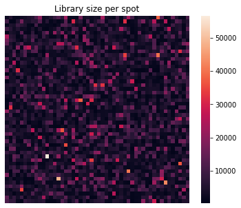

```python
plt.figure(figsize=(6, 5))
sns.heatmap(synth_df.sum(1).to_numpy().reshape(50, -1))
plt.axis('off')
plt.title('Library size per spot')
plt.show()
```

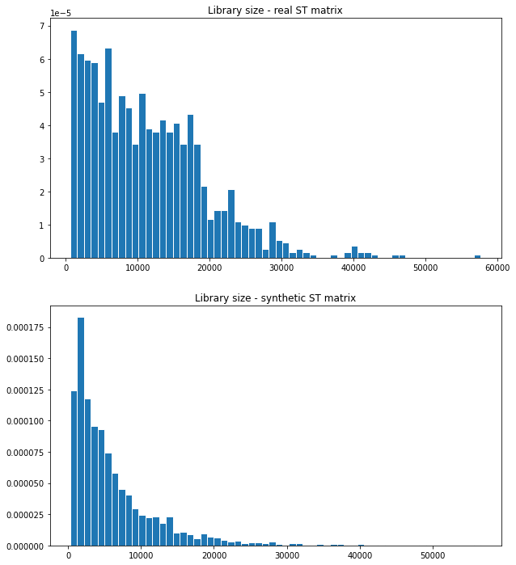

```python
# Comparison of real & synthetic ST library size histogram

fig, (ax1, ax2) = plt.subplots(2, 1, figsize=(10, 12))

ax1.hist(adata.X.sum(1), bins=60, density=True, edgecolor='white')
ax1.set_title('Library size - real ST matrix')

ax2.hist(synth_df.sum(1), bins=60, density=True, edgecolor='white')
ax2.set_title('Library size - synthetic ST matrix')

plt.show()
```

Save simulations to output

- Spot x Gene synthetic matrix
- Ground-truth cell count (density)
- Ground-truth cell proportion

```python
%ls ../../sc_transcriptome_ana/simulation/data_cell2loc/
```

```python
# Save simulations to file
out_path = '../../sc_transcriptome_ana/simulation/data_cell2loc/'
```

```python
synth_df.to_csv(
    os.path.join(out_path, 'counts.st_synth.csv'),
    index=True
)

cell_count_df.to_csv(
    os.path.join(out_path, 'members.st_synth.csv'),
    index=True
)

proportion_df.to_csv(
    os.path.join(out_path, 'proportions.st_synth.csv'),
    index=True
)
```

#### [Benchmark] Check correlation between signature mean gexp. & ground-truth proportion

```python
# Load signature gene dict

# specify signature genes directory
sig_genes_df = pd.read_csv('../../sc_transcriptome_ana/simulation/data/tnbc_signature.csv', header=[0])
sig_genes_dict = sig_genes_df.to_dict(orient='list')
```

```python
out_path = '../../sc_transcriptome_ana/simulation/data_cell2loc/'

synth_df = pd.read_csv(
    os.path.join(out_path, 'counts.st_synth.csv'),
    index_col=[0],
    header=[0]
)

cell_count_df = pd.read_csv(
    os.path.join(out_path, 'members.st_synth.csv'),
    index_col=[0],
    header=[0]
)

proportion_df = pd.read_csv(
    os.path.join(out_path, 'proportions.st_synth.csv'),
    index_col=[0],
    header=[0]
)
```

```python
# Parallel comparison with Stereoscope-like simulation (without normalization)

stereo_sim_path = '../../sc_transcriptome_ana/simulation/data_stereo/'

stereo_synth_df = pd.read_csv(
    os.path.join(stereo_sim_path, 'counts.st_synth.csv'),
    index_col=[0],
    header=[0]
)

stereo_cell_count_df = pd.read_csv(
    os.path.join(stereo_sim_path, 'members.st_synth.csv'),
    index_col=[0],
    header=[0]
)

stereo_proportion_df = pd.read_csv(
    os.path.join(stereo_sim_path, 'proportions.st_synth.csv'),
    index_col=[0],
    header=[0]
)
```

```python
def disp_density_gexp(expr_df, prop_df, sig_dict, normalize=False):
    """
    Display relation of ground-truth cell-type proportion vs.
    average of cell-type specific marker gene expression
    """

    cell_types = prop_df.columns
    assert len(sig_dict) == len(cell_types) and \
           np.array_equal(sorted(sig_dict.keys()), sorted(cell_types)), \
        "Unequal length of cell types in signature dictionary & ground-truth proportion dataframe"

    expr_df_copy = expr_df.copy()

    if normalize:
        med_libsize = expr_df_copy.sum(1).median()
        expr_df_copy = expr_df_copy.div(expr_df_copy.sum(1), axis=0) * med_libsize

    # Average expression of cell-type specific marker genes
    sig_expr = np.zeros(prop_df.shape)
    for i, ct in enumerate(prop_df.columns):
        sig_genes = np.intersect1d(sig_dict[ct], expr_df.columns)
        expr = expr_df_copy[sig_genes].mean(1)
        sig_expr[:, i] = expr

    sig_expr = sig_expr / np.expand_dims(sig_expr.sum(1), axis=1) # normalize expression to proportion
    sig_expr_df = pd.DataFrame(
        sig_expr,
        index=expr_df.index,
        columns = prop_df.columns
    )

    # Plotting
    r = 0
    c = 0
    nrow = np.ceil(len(cell_types) // 3).astype(np.uint8)
    fig, axes = plt.subplots(nrow, 3, figsize=(15, 15))

    for i, ct in enumerate(cell_types):
        if c % 3 == 0 and c > 0:
            r += 1
            c = 0

        xx = prop_df[ct].to_numpy()
        yy = sig_expr_df[ct].to_numpy()

        ax = axes[r, c]
        ax.scatter(xx, yy, alpha=0.5, marker='.', cmap=plt.cm.Greens)
        ax.set_xlim([0, 1])
        ax.set_ylim([0, 1])
        ax.set_xlabel('Ground-truth proportion')
        ax.set_ylabel('Mean sig gexp')
        ax.set_title(ct)

        c += 1

    plt.tight_layout()
    # plt.suptitle('Cell2Location simulation (w/ spatial dependencies)', y=1.05, fontsize=20)
    plt.show()
```

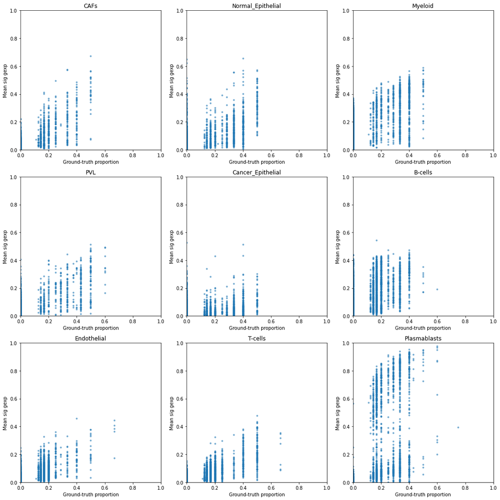

```python
# Cell2location simulation (w/ spatial dependencies)
disp_density_gexp(synth_df, proportion_df, sig_genes_dict, normalize=False)
```

```python
# Stereoscope simulation (without spatial dependencies)
disp_density_gexp(stereo_synth_df, stereo_proportion_df, sig_genes_dict, normalize=False)
```

[output not shown]